# STAT 450 Tutorial

Nam Hee Gordon Kim

January 11, 2018

## About NHGK

My name is Nam. My name does not rhyme with Sam but with Islam and lip balm. I am originally from South Korea. However, I don’t listen to K-Pop.

## Favorite Equation

My favorite equation is the Bayes’ Rule equation.

$$P(A | B) = \frac{P(B|A) P(A)}{P(B)}$$

Bayes’ Rule is widely used in statistics and probability. The Bayesian approach to artificial intelligence and machine learning is rapidly gaining popularity.

## Favorite Dataset

```r
summary(trees)
```

```
##      Girth           Height       Volume
##  Min.   : 8.30   Min.   :63   Min.   :10.20
##  1st Qu.:11.05   1st Qu.:72   1st Qu.:19.40
##  Median :12.90   Median :76   Median :24.20
##  Mean   :13.25   Mean   :76   Mean   :30.17
##  3rd Qu.:15.25   3rd Qu.:80   3rd Qu.:37.30
##  Max.   :20.60   Max.   :87   Max.   :77.00
```

```r
head(trees, 5)
```

```
##   Girth Height Volume
## 1   8.3     70   10.3
## 2   8.6     65   10.3
## 3   8.8     63   10.2
## 4  10.5     72   16.4
## 5  10.7     81   18.8
```

For this dataset, I show that tall trees tend to have larger girth. The definition of “tall” trees is above average height.

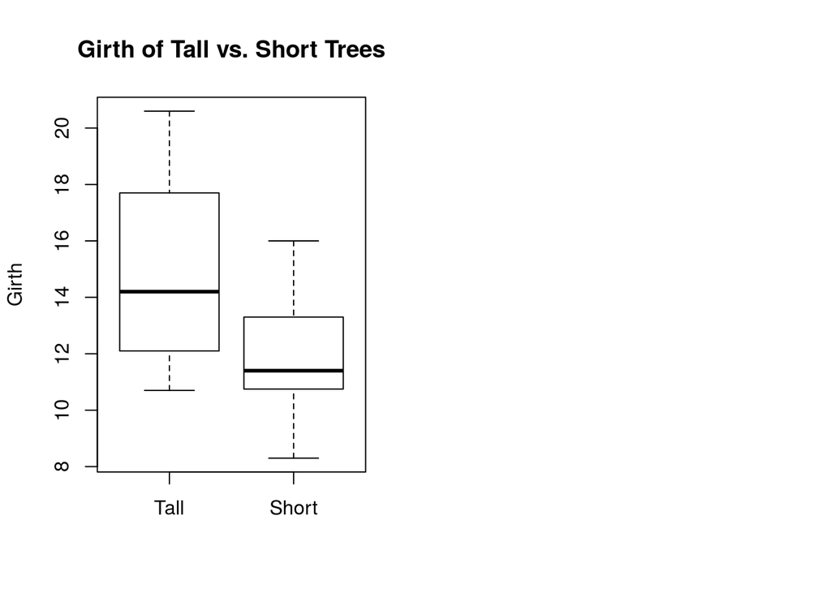

$$H_0: \text{ tall and short trees have the same population mean of girth }$$

which is formalized as

$$H_0: \mu_{\text{tall}} = \mu_{\text{short}}$$

```r
t.test(Girth ~ tall, data=trees)
```

```
##
##  Welch Two Sample t-test
##
## data:  Girth by tall
## t = -3.2911, df = 24.146, p-value = 0.003061
## alternative hypothesis: true difference in means is not equal to 0
## 95 percent confidence interval:
##  -5.290160 -1.213174
## sample estimates:
## mean in group FALSE  mean in group TRUE
##            11.67500            14.92667
```

Test statistic $t$ returned -3.29. The $p$-value was 0.003. With significance level 95%, we reject $H_0$ in favor of the difference in population means.

## Acknowledgments

This project was funded by My Parents Grant as well as Internship Money.